# Technical Analysis Indicators

**Install package for technical analysis**

Install and load library

```r
install.packages("TTR")
install.packages('xtsExtra')
library(quantmod)
```

```
Error: package TTR required by quantmod could not be found
```

```r
library(quantmod)
library(TTR)
library(xts)
library(zoo)
```

Load historical data (Input)

```r
pttep     <- read.csv("data/PTTEP.csv", stringsAsFactors = FALSE)
head(pttep, n = 3)
```

|  | Index | PTTEP.BK.Open | PTTEP.BK.High | PTTEP.BK.Low | PTTEP.BK.Close | PTTEP.BK.Volume | PTTEP.BK.Adjusted |
| --- | --- | --- | --- | --- | --- | --- | --- |
| 1 | 2015-01-05 | 112.5 | 113.0 | 107.0 | 107.0 | 7780300 | 92.53233 |
| 2 | 2015-01-06 | 104.5 | 108.0 | 103.0 | 107.0 | 8435700 | 92.53233 |
| 3 | 2015-01-07 | 105.0 | 107.5 | 104.5 | 106.5 | 7555300 | 92.09995 |

```r
class(pttep)
```

```
[1] "data.frame"
```

Notice that Index column is character class. We need to convert it to Date before converting to xts.

```r
#Convert Index column from character to date.
pttep[,1] <- as.Date(pttep[,1])
head(pttep, n = 3)
```

|  | Index | PTTEP.BK.Open | PTTEP.BK.High | PTTEP.BK.Low | PTTEP.BK.Close | PTTEP.BK.Volume | PTTEP.BK.Adjusted |
| --- | --- | --- | --- | --- | --- | --- | --- |
| 1 | 2015-01-05 | 112.5 | 113.0 | 107.0 | 107.0 | 7780300 | 92.53233 |
| 2 | 2015-01-06 | 104.5 | 108.0 | 103.0 | 107.0 | 8435700 | 92.53233 |
| 3 | 2015-01-07 | 105.0 | 107.5 | 104.5 | 106.5 | 7555300 | 92.09995 |

```r
#Convert to xts object
pttep.xts <- as.xts(pttep[,-1], order.by = pttep$Index)
#subset data
pttep.xts <- pttep.xts["2018-01-01/"]
head(pttep.xts, n = 3)
```

```
           PTTEP.BK.Open PTTEP.BK.High PTTEP.BK.Low PTTEP.BK.Close PTTEP.BK.Volume
2018-01-03         100.5           103        99.75          101.5        15577400
2018-01-04         104.0           106       103.00          106.0        22761100
2018-01-05         107.0           108       105.50          107.0        21279300
           PTTEP.BK.Adjusted
2018-01-03          97.91709
2018-01-04         102.25825
2018-01-05         103.22295
```

```r
class(pttep.xts)
```

```
[1] "xts" "zoo"
```

**Moving Averages**

Calculate 10-day Simple Moving Average (SMA) of the adjusted close price column.

```r
sma10 <- SMA((pttep.xts$PTTEP.BK.Adjusted), n = 10)
head(sma10, n = 20)
```

```
                SMA
2018-01-03       NA
2018-01-04       NA
2018-01-05       NA
2018-01-08       NA
2018-01-09       NA
2018-01-10       NA
2018-01-11       NA
2018-01-12       NA
2018-01-15       NA
2018-01-16 104.0912
2018-01-17 105.2488
2018-01-18 106.0206
2018-01-19 106.7923
2018-01-22 107.7570
2018-01-23 108.7217
2018-01-24 109.7347
2018-01-25 110.6029
2018-01-26 111.4229
2018-01-29 112.1464
2018-01-30 112.6770
```

Calculate 20-day Simple Moving Average (SMA) of the adjusted close price column.

```r
sma20 <- SMA((pttep.xts$PTTEP.BK.Adjusted), n = 20)
head(sma20, n = 30)
```

```
                SMA
2018-01-03       NA
2018-01-04       NA
2018-01-05       NA
2018-01-08       NA
2018-01-09       NA
2018-01-10       NA
2018-01-11       NA
2018-01-12       NA
2018-01-15       NA
2018-01-16       NA
2018-01-17       NA
2018-01-18       NA
2018-01-19       NA
2018-01-22       NA
2018-01-23       NA
2018-01-24       NA
2018-01-25       NA
2018-01-26       NA
2018-01-29       NA
2018-01-30 108.3841
2018-01-31 109.2282
2018-02-01 109.9758
2018-02-02 110.7235
2018-02-05 111.3988
2018-02-06 111.9294
2018-02-07 112.4723
2018-02-08 112.8441
2018-02-09 113.0212
2018-02-12 113.2748
2018-02-13 113.4783
```

Plot moving average crossover

```r
sma <- cbind(sma10, sma20, pttep.xts$PTTEP.BK.Adjusted)
colnames(sma) <- c("sma10", "sma20", "price")
head(sma)
```

```
           sma10 sma20     price
2018-01-03    NA    NA  97.91709
2018-01-04    NA    NA 102.25825
2018-01-05    NA    NA 103.22295
2018-01-08    NA    NA 101.77589
2018-01-09    NA    NA 103.22295
2018-01-10    NA    NA 103.22295
```

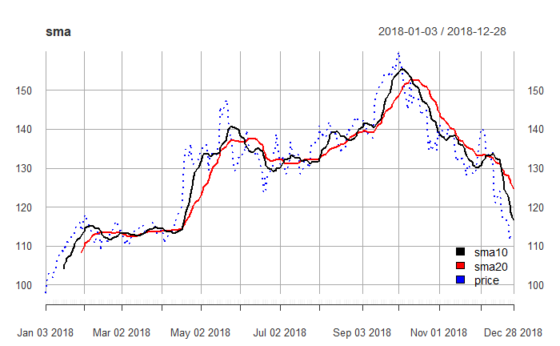

```r
plot.xts(sma, screeens = factor(1,1), legend.loc = "bottomright", auto.legend = TRUE,
         col = c("black", "red", "blue"), lty = c(1, 1, 3))
```

**Bollinger Bands**

- A set of lines plotted two standard deviations (positively and negatively) away from a simple moving average of the security’s price. Bollinger band was developed by famous technical trader John Bollinger. By default, the period is n = 20.

```r
bb20 <- BBands(pttep.xts$PTTEP.BK.Adjusted, n = 20, sd=2.0)
head(bb20, n = 30)
```

```
                  dn     mavg       up      pctB
2018-01-03        NA       NA       NA        NA
2018-01-04        NA       NA       NA        NA
2018-01-05        NA       NA       NA        NA
2018-01-08        NA       NA       NA        NA
2018-01-09        NA       NA       NA        NA
2018-01-10        NA       NA       NA        NA
2018-01-11        NA       NA       NA        NA
2018-01-12        NA       NA       NA        NA
2018-01-15        NA       NA       NA        NA
2018-01-16        NA       NA       NA        NA
2018-01-17        NA       NA       NA        NA
2018-01-18        NA       NA       NA        NA
2018-01-19        NA       NA       NA        NA
2018-01-22        NA       NA       NA        NA
2018-01-23        NA       NA       NA        NA
2018-01-24        NA       NA       NA        NA
2018-01-25        NA       NA       NA        NA
2018-01-26        NA       NA       NA        NA
2018-01-29        NA       NA       NA        NA
2018-01-30  98.23821 108.3841 118.5300 0.7686092
2018-01-31  99.93260 109.2282 118.5238 0.7996657
2018-02-01 100.63767 109.9758 119.3140 0.8874017
2018-02-02 101.27398 110.7235 120.1730 0.8943225
2018-02-05 102.70322 111.3988 120.0943 0.7232701
2018-02-06 104.03605 111.9294 119.8227 0.6206894
2018-02-07 105.62457 112.4723 119.3200 0.6175047
2018-02-08 106.99688 112.8441 118.6913 0.4368960
2018-02-09 107.69125 113.0212 118.3512 0.2751697
2018-02-12 108.25874 113.2748 118.2908 0.5804234
2018-02-13 108.94170 113.4783 118.0150 0.4031956
```

Plot Bollinger Band

```r
Bband.Data <- data.frame(pttep[pttep$Index >= "2018-01-01",c(1,7)], bb20)
head(Bband.Data)
```

|  | Index | PTTEP.BK.Adjusted | dn | mavg | up | pctB |
| --- | --- | --- | --- | --- | --- | --- |
| 731 | 2018-01-03 | 97.91709 | NA | NA | NA | NA |
| 732 | 2018-01-04 | 102.25825 | NA | NA | NA | NA |
| 733 | 2018-01-05 | 103.22295 | NA | NA | NA | NA |
| 734 | 2018-01-08 | 101.77589 | NA | NA | NA | NA |
| 735 | 2018-01-09 | 103.22295 | NA | NA | NA | NA |
| 736 | 2018-01-10 | 103.22295 | NA | NA | NA | NA |

```r
plot(Bband.Data$Index, Bband.Data$PTTEP.BK.Adjusted, pch = 16, cex = 0.5)
lines(Bband.Data$Index, Bband.Data$PTTEP.BK.Adjusted, col = 'red')
```

```r
lines(Bband.Data$Index, Bband.Data$up, col = 'brown')
lines(Bband.Data$Index, Bband.Data$dn, col = 'brown')
```

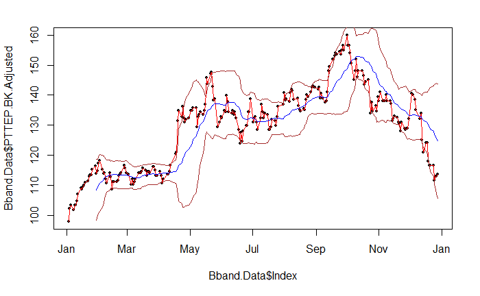

```r
lines(Bband.Data$Index, Bband.Data$mavg, col = 'blue')
```

**Relative Strength Indicator - RSI** The Relative Strength Index (RSI), developed by J. Welles Wilder, is a momentum oscillator that measures the speed and change of price movements. The RSI oscillates between zero and 100. Traditionally the RSI is considered overbought when above 70 and oversold when below 30. Source: Fidelity.com

```r
rsi14 <- RSI(pttep.xts$PTTEP.BK.Adjusted, n = 14)
head(rsi14, n = 20)
```

```
                rsi
2018-01-03       NA
2018-01-04       NA
2018-01-05       NA
2018-01-08       NA
2018-01-09       NA
2018-01-10       NA
2018-01-11       NA
2018-01-12       NA
2018-01-15       NA
2018-01-16       NA
2018-01-17       NA
2018-01-18       NA
2018-01-19       NA
2018-01-22       NA
2018-01-23 89.74357
2018-01-24 90.01918
2018-01-25 90.01918
2018-01-26 91.12546
2018-01-29 91.62529
2018-01-30 79.56095
```

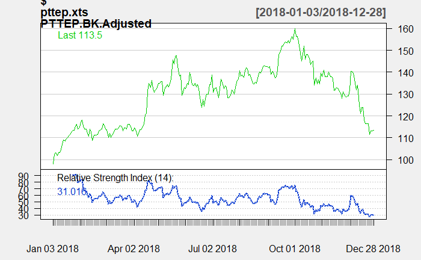

```r
chartSeries(pttep.xts$PTTEP.BK.Adjusted, theme = chartTheme("white"), TA = 'addRSI(n = 14)')
```

# Visualize RSI and Bollinger Bands in one chart

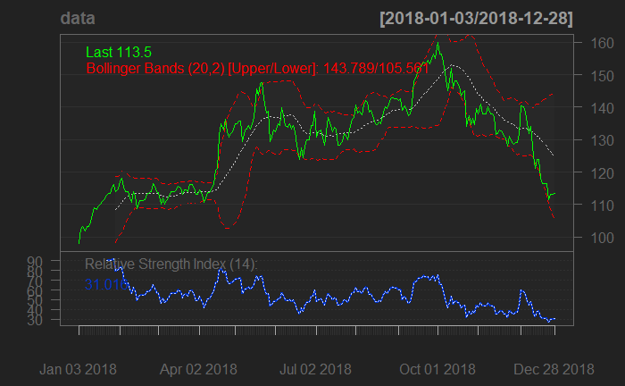

```r
data <- pttep.xts$PTTEP.BK.Adjusted
chartSeries(data, theme = chartTheme("black"), TA = c(addBBands(),addRSI()))
```

**MACD** Moving Average Convergence Divergence is a trend-following momentum indicator. The MACD is calculated by subtracting the 26-period Exponential Moving Average (EMA) from the 12-period EMA. If the 12-period EMA is above the 26-period EMA, the MACD will be above its “baseline” of zero. If the shorter EMA is below the longer EMA, the MACD will be below its baseline. Traders may buy the security when the MACD crosses above its signal line and sell, or short, the security when the MACD crosses below the signal line.

```r
macd <- MACD(pttep.xts$PTTEP.BK.Adjusted, nFast = 12, nSlow = 26, nSig = 9, maType = SMA)
head(macd, n = 30)
```

```
               macd signal
2018-01-03       NA     NA
2018-01-04       NA     NA
2018-01-05       NA     NA
2018-01-08       NA     NA
2018-01-09       NA     NA
2018-01-10       NA     NA
2018-01-11       NA     NA
2018-01-12       NA     NA
2018-01-15       NA     NA
2018-01-16       NA     NA
2018-01-17       NA     NA
2018-01-18       NA     NA
2018-01-19       NA     NA
2018-01-22       NA     NA
2018-01-23       NA     NA
2018-01-24       NA     NA
2018-01-25       NA     NA
2018-01-26       NA     NA
2018-01-29       NA     NA
2018-01-30       NA     NA
2018-01-31       NA     NA
2018-02-01       NA     NA
2018-02-02       NA     NA
2018-02-05       NA     NA
2018-02-06       NA     NA
2018-02-07 4.379388     NA
2018-02-08 3.806731     NA
2018-02-09 3.300599     NA
2018-02-12 2.967658     NA
2018-02-13 2.384046     NA
```

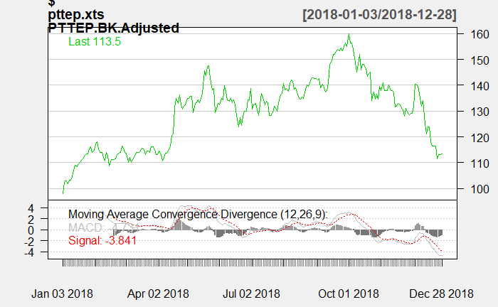

```r
#plot MACD
chartSeries(pttep.xts$PTTEP.BK.Adjusted, theme = chartTheme("white"), TA = 'addMACD(fast = 12, slow = 26, signal = 9)')
```

```r
#or for default function
#chartSeries(pttep.xts$PTTEP.BK.Adjusted, theme = chartTheme("white"), TA = 'addMACD()')
```